# Modelling Water Flow with Shrinkage Methods

Rage Against The Machine Learning

# Introduction

## Water Flow and Water Level

Statistical prediction of water flow (Norwegian: vannføring) and water level (Norwegian: vannstand) in rivers is an increasingly important problem. The problem is tightly linked with the prediction of floods. Because of climate change, the occurrence of floods is predicted to increase, and possibly in areas where floods have been historically rare:

[(Norwegian) Klima, nå og i framtiden](https://www.nve.no/klima/klima-na-og-i-framtiden/?ref=mainmenu)

Floods are potentially deadly for both humans and wildlife, and have huge economic consequences each year. Rivers are also an extremely important resource in many countries. In Norway, 90 % of produced electricity comes from hydropower:

[(Norwegian) Kraftproduksjon](https://energifaktanorge.no/norsk-energiforsyning/kraftforsyningen/)

Good statistical models for water flow and water level are important in order to optimize the production of electricity. The *Norwegian Water Resources and Energy Directorate (NVE)* has about 600 water level measurement stations all over Norway:

[(Norwegian) Stasjonsnettet](https://www.nve.no/hydrologi/vannstand-og-vannforing/stasjonsnettet/)

Measurements are going as far back as the 1940’s. The *Norwegian Meteorological Institute (MET)* is responsible for the developed weather measurement and forecasting infrastructure in Norway. Many variables obtained by weather measurements, such as temperature, precipitation and snow content are traditionally used in physical models for water flow and water level. These physical models usually require parameter fitting and/or field experiments in order to yield good predictions.

With the wealth of data available, it is worth considering purely data-driven approaches using measurements from NVE and MET to predict water flow and water level. In this report we will attempt to apply statistical shrinkage models to predict water flow at Eggafossen in Trøndelag, Norway. NVE was kind enough to give us water measurements and predictions from the model they are currently using, as well as weather data obtained from MET.

## Eggafossen

Eggafossen is a location along the Gaula river in Trøndelag. Gaula as a whole is approximately 153 kilometers long and drains a watershed of about 3,661 square kilometers. The river runs through several populated areas as well as along the county road fv30, the highway E6, and the Rørosbanen train rail.

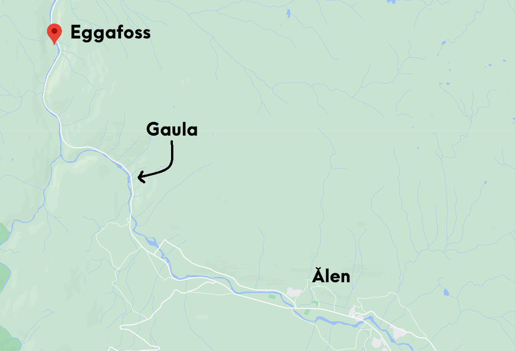

Source: Google maps

> The risk of flood was underestimated because of several factors. The first percipitation predictions were too low. NVE’s hydrological models were inadequate for the situation…

This motivates research on better prediction models.

## The HBV model

The [Hydrologiska Byråns Vattenbalansavdelig (HBV) model](https://en.wikipedia.org/wiki/HBV_hydrology_model) is a physical model designed for simulating river flow based on an advanced water balance calculation, specifically designed for rivers in Scandinavia. The model is somewhat difficult to approach unless one has experience with hydrology, and we will not go into details here.

Because the HBV model most likely requires a data-driven fitting process, it is worth asking: Is it possible to make comparable predictions to the HBV model using a purely data-driven model? The data driven model would have access to the same data as the HBV model. If a purely data-driven model is shown to be as good or nearly as good as the HBV model, the model can easily be transferred to other measurement stations. Furthermore, data-driven models can be used for inference in order to assess what actually causes water flow, and can be used for confidence intervals and uncertainty measurements more easily than a physical model.

# Exploring the Data

The data from various .csv-files from NVE is gathered into the file `raw_data_eggafoss.rds`.

```r
# Importing data from Eggafoss
eggafoss = readRDS("data/raw_data_eggafoss.rds")

# Transform column names
names(eggafoss)[6:8] <- c("vannføring", "vannstand", "modellertvannføring")
names(eggafoss)
```

```
## [1] "dato"                "nedbør"              "snødekningsgrad"
## [4] "snøvannekvivalent"   "temperatur"          "vannføring"
## [7] "vannstand"           "modellertvannføring"
```

The data set consists of 8 features. They are all measured at 12:00 midday at the date of measurement.

- `dato`: date of measurements [yyyy-mm-dd]
- `nedbør`: rainfall [m]
- `snødekningsgrad`: snow coverage [%]
- `snøvannekvivalent`: snow’s water equivalent [m]
- `temperatur`: temperature [°C]
- `vannføring`: water flow in river [m³/s]
- `vannstand`: water level in river [m]
- `modellertvannføring`: HBV’s modelled water flow [m³/s]

We will use `vannføring` as the response. We begin by gauging basic information about the data.

```
## Classes 'data.table' and 'data.frame':   28764 obs. of  8 variables:
##  $ dato               : Date, format: "1941-04-01" "1941-04-02" ...
##  $ nedbør             : num  NA NA NA NA NA NA NA NA NA NA ...
##  $ snødekningsgrad    : num  NA NA NA NA NA NA NA NA NA NA ...
##  $ snøvannekvivalent  : num  NA NA NA NA NA NA NA NA NA NA ...
##  $ temperatur         : num  NA NA NA NA NA NA NA NA NA NA ...
##  $ vannføring         : num  NA NA NA NA 1.37 ...
##  $ vannstand          : num  0 0 0 0 1.28 1.27 1.27 1.27 1.3 1.35 ...
##  $ modellertvannføring: num  NA NA NA NA NA NA NA NA NA NA ...
##  - attr(*, ".internal.selfref")=<externalptr>
##  - attr(*, "sorted")= chr "dato"
```

```
##       dato                nedbør      snødekningsgrad  snøvannekvivalent
##  Min.   :1941-04-01   Min.   :0.000   Min.   :  0.00   Min.   :0.000
##  1st Qu.:1960-12-07   1st Qu.:0.000   1st Qu.:  0.10   1st Qu.:0.000
##  Median :1980-08-15   Median :0.001   Median : 99.90   Median :0.093
##  Mean   :1980-08-15   Mean   :0.003   Mean   : 61.83   Mean   :0.175
##  3rd Qu.:2000-04-23   3rd Qu.:0.004   3rd Qu.:100.00   3rd Qu.:0.317
##  Max.   :2019-12-31   Max.   :0.090   Max.   :100.00   Max.   :0.994
##                       NA's   :6119    NA's   :6119     NA's   :6119
##    temperatur        vannføring        vannstand     modellertvannføring
##  Min.   :-39.500   Min.   :  0.443   Min.   :0.000   Min.   :  0.000
##  1st Qu.: -5.320   1st Qu.:  2.731   1st Qu.:1.440   1st Qu.:  1.383
##  Median :  0.490   Median :  6.665   Median :1.700   Median :  8.661
##  Mean   :  0.211   Mean   : 17.731   Mean   :1.826   Mean   : 18.622
##  3rd Qu.:  6.730   3rd Qu.: 19.089   3rd Qu.:2.110   3rd Qu.: 19.771
##  Max.   : 21.070   Max.   :394.590   Max.   :3.930   Max.   :248.964
##  NA's   :6119      NA's   :4                         NA's   :6119
```

We notice that `dato` is given in Date-format, while the other feaures are numerical. Most features, like `nedbør`, `snødekningsgrad`, `vannføring`, `vannstand` og `modellertvannføring`, takes on numerical values greater or equal to zero, while `temperatur` can attain negative values as well. `snødekningsgrad` is given in percentage, so its range is between $0$ and $100$. The `dato` column shows that the collection of the data started in 1941 and goes all the up to the end of 2019, which means we have 78 years of daily data for some of our features. There also seems to be a lot of missing values is the dataset, which we will deal with below.

# Preprocessing and Exploratory Data Analysis

Before we can start fitting our data to different models, we have to preprosess the data and do some exploratory data analysis. The goal of this is making sure we have no missing values and that the data is transformed the way we want it, as well as get a initial feel for the features and their correlation with the response and with each other.

## Handling Missing values

From the summary of the data above, we see that we are missing some values. We make a plot of the missing values to see just how much we are missing.

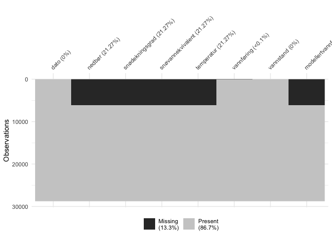

We see that we only have missing data for a certain range of dates. From 1941 to 1958 we only have data on `vannføring` and `vannstand`, but nothing else. Since there is not much use predicting `vannføring` only from `vannstand` before 1958, we decide to remove these years from the dataset.

```r
# Remove data between 1941 and 1958
eggafoss = eggafoss[6120:28764, ]

# Any NA's left?
any(is.na(eggafoss))
```

```
## [1] FALSE
```

After removing the missing data we are left with 22645 observations from Eggafoss, which includes daily data from January 1st 1958 to December 31st 2019.

```
## [1] 22645     8
```

## Examining Correlation

Now that we have removed all the missing values, we start exploring some of the underlying features of the data. We start by looking at the correlation between the covariates and the response.

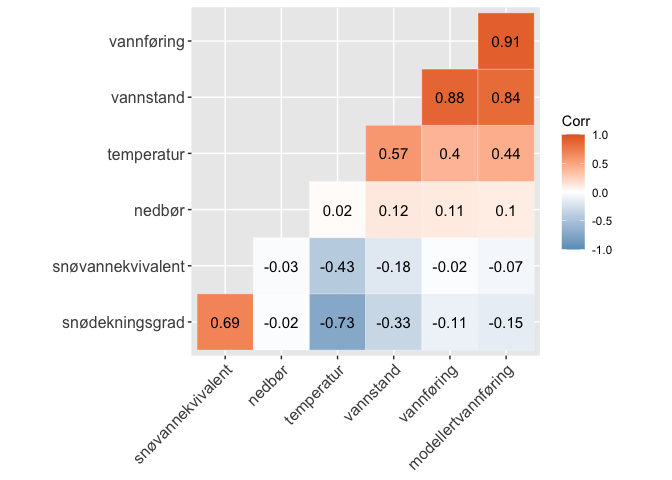

We see that the response `vannføring` is, unsurprisingly, most correlated with `modellertvannføring` and `vannstand`. We make a scatterplot of both of them against the response to see in more detail how they affect each other. To avoid to many points at once, we sample 3000 points from our data so that the underlying structure of the data becomes clearer. The orange line shows the linear regression line from the data.

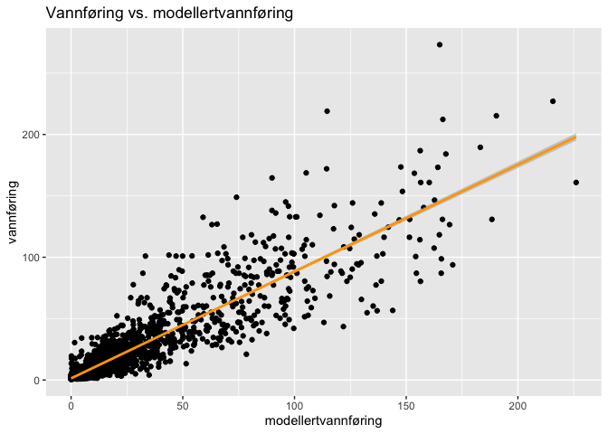

We will use the results from the HBV model as a baseline for the results from our own model, and not include the data from the HBV model when fitting the data.

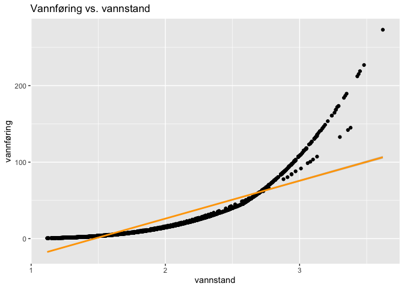

The height of water in a river is tightly linked with water flow. We see that the relationship is not linear. `vannføring` is most likely calculated by NVE based on `vannstand`, so we will not include `vannstand` in our models. The other features, like `temperatur` and `snødekningsgrad` could be inferred from good weather forecasting models, and we therefore include these in our models. This is however not entirely realistic, which is something we will discuss towards the end of this article.

We will also look at some of the covariates which have a high correlation with each other. This type of multicollinearity can cause problems in regular linear regression models, as it increases the standard error of the coefficients and thus some of the covariates can seem insignificant, even though they are not.

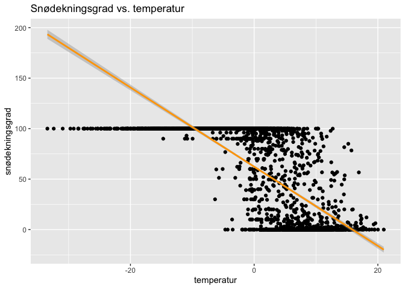

The correlation between `temperatur` and `snødekningsgrad` is -0.73 and we see from the plot that there is a negative trend. Intuitively, the amount of snow decreases when the temperature increases. Below -10°C the snow coverage is at 100%. It starts decreasing once the temperature increases and winter becomes summer.

Between `snødekningsgrad` and `snøvannekvivalent` there is also a strong correlation of 0.69. The more snow covers the ground, the more water is produced when the show melts. Since `snødekningsgrad` only gives us the percentage of the ground covered by snow, it stops at 100%, and thus will not give us a good indication of how much snow there actually is on the ground. `snøvannekvivalent` can provide a better measure of this. Since the values are so similar, both might not be needed in our model, and might be removed, or set close to zero, by the shrinkage methods.

## Understanding the Seasonality of the Response

One of the features of our original data set is `dato`, the date at which each observation is measured. We cannot use this feature directly in building our models, but based on the analysis above, it might be beneficial to add some information about the time of each measurement, as seasonality is present in the data. To make an even stronger argument of this we look the response `vannføring` as a time series.

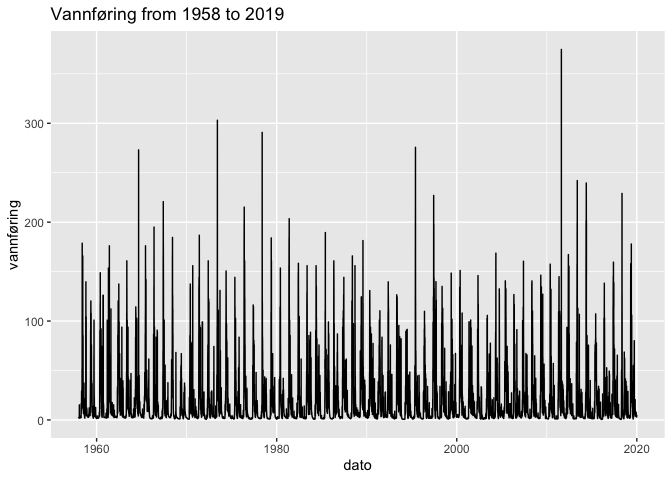

From the plot above we see that there is definitely some trends in the data that repeats yearly. We take a closer look by making a boxplot of the `vannføring` for each month in a year. We would expect the water flow to usually be very low, with low variance, during the winter month. During spring and fall the average water flow should be a lot higher, and also have more variance.

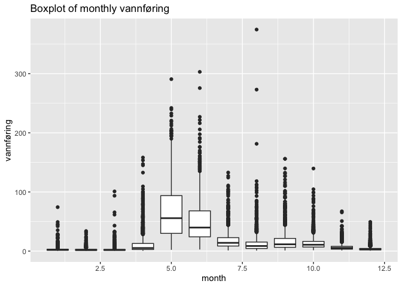

The boxplot shows what we expected. Based on the plot we make an argument that an interesting covariate to add to our model is `month`, which gives information about which month the observaion is from. We could also have chosen to include season instead of month, but because of the diffuculty to divide the pattern we see into seasons we might loose some information, and instead choose to do the finer monthly division. Adding more variables than necessary should not be a problem in this project, as the regularization methods will remove the variables which are not significant for the prediction of the response.

## Adding information about previous days

We will attempt to model the response `vannføring`, here denoted $y(t)$ with $t$ as a time variable at day $k$, as
$$y(t_k) = \sum_{i \in \text{covariates}}\sum_{j = 0}^\text{days} \beta_{i,j}x_i(t_{k - j}) + \sum_{j = 1}^\text{days} \beta_{\texttt{vannføring},j}x_\texttt{vannføring}(t_{k - j}),$$
where $x_i$ is a covariate in $\text{covariates} = [\texttt{nedbør}, \texttt{temperatur}, \texttt{snøvannekvivalent}, \texttt{snødekningsgrad}]$. The response `vannføring` is a linear combination of other covariates at the same and previous days, and also the the values of `vannføring` from previous days. This way our model will capture not only the relevant parameters from the same day (assuming we have a good weather forecast, so precipitation, temperature and snow is known), but relevant parameters from previous days. The motivation behind this approach is that, for rivers, we would expect the water flow to exhibit some delay in the response of the other covariates. For example, a heavy rainfall might lead to large water flow after a couple of days as it takes time for the rainfall to travel through the soil into the river. In addition, we would expect a large change in snow (melting) will lead to large water flow when this melted water reaches the river.

A linear combination of the same covariates over time can potentially capture not only the value of the data at previous days, but also the rate of change over previous days. It can also potentially extrapolate `vannføring` on the current day based on `vannføring` from the previous days.

We want to emphasize that a linear model might not be the best way to model the response in this example, but as the problem will include a lot of covariates, some of which are highly correlated, it hopefully makes sense to apply shrinkage models, which is the goal of this project. We should also mention that we use MSE as the error measure in this project. For a problem like this, where it is more important for our model to predict high water flow compared to low, there might be other error measures of interest as well.

# Modelling

We have chosen to use 40 years of data to train our model. Even though we have data from the last 60 years, we expect the quality of the data to have increased somewhat from 1958 to 2019, thus we find it unnecessary to include all the data. We also think that 40 years of data should be sufficient to capture the underlying trends. We include data from the past 7 days as covariates, such that we might capture how snow melting, temperature change and precipitation can influence the response at a current date. If the later days do not influence the response, we hope that the models will detect this and remove them from the model.

We train on the observation between 1977 and 2017, and test the models on data from the years 2018 and 2019. The dimensions of the test and training set can be seen below. We will try to fit the data on traditional linear models, as well as some shrinkage methods to see which ones are best at prediction and inference. It is also of interest to see if we can beat HBV’s modeled `vannføring` with our purely data-driven models.

All the data is standardized and centered before we apply any of the models. Using the test and training sets described above the training set will consist of **14968** observations, while the test set will consist of **723** observations. After having removed `vannstand`, `modellertvannføring` and `dato`, as well as added covariates from previous days and months, we have **50** covariates.

```r
years = 40 # max 60, min 3 (since 2 years are automatically used for testing)
days = 7

# Function creates and splits dataset as discussed earlier ()
data = data_preparation(eggafoss, years, days) # See the markdown file for the function declaration
df = data[[1]]
train = data[[2]]
test = data[[3]]
x_train = data[[4]]
y_train = data[[5]]
x_test = data[[6]]
y_test = data[[7]]
```

## Traditional linear models

First we start of by fitting a linear model, a weighed linear model, and a best subset selection to our data. This is done such that we get an idea of which covariates might be significant to our model. Moreover, these methods then provide a benchmark for the shrinkage methods when it comes to prediction. We also hope that by using model selection we can increase the interpretability, and maybe also the prediction, of the linear model.

### Linear regression

We begin by fitting an the ordinary linear regression model:

```r
lm.fit = lm(vannføring~.-dato -vannstand -modellertvannføring, data = train)
summary(lm.fit)
```

```
##
## Call:
## lm(formula = vannføring ~ . - dato - vannstand - modellertvannføring,
##     data = train)
##
## Residuals:
##     Min      1Q  Median      3Q     Max
## -6.6704 -0.0508  0.0013  0.0464  9.6303
##
## Coefficients:
##                           Estimate Std. Error t value Pr(>|t|)
## (Intercept)              8.370e-04  2.128e-03   0.393 0.694097
## nedbør                   2.723e-01  2.820e-03  96.584  < 2e-16 ***
## snødekningsgrad          2.010e-02  1.306e-02   1.538 0.123948
## snøvannekvivalent       -9.759e+00  1.191e-01 -81.969  < 2e-16 ***
## temperatur               4.149e-02  6.698e-03   6.194 6.02e-10 ***
## snøvannekvivalent1dager  1.130e+01  2.149e-01  52.600  < 2e-16 ***
## snødekningsgrad1dager    7.632e-03  1.781e-02   0.429 0.668203
## nedbør1dager            -6.850e-02  3.625e-03 -18.895  < 2e-16 ***
## temperatur1dager        -1.424e-02  9.343e-03  -1.525 0.127381
## vannføring1dager         7.632e-01  8.368e-03  91.206  < 2e-16 ***
## snøvannekvivalent2dager -1.247e+00  2.369e-01  -5.263 1.44e-07 ***
## snødekningsgrad2dager    4.853e-03  1.782e-02   0.272 0.785387
## nedbør2dager            -6.793e-03  3.672e-03  -1.850 0.064365 .
## temperatur2dager        -2.398e-03  9.562e-03  -0.251 0.801979
## vannføring2dager        -2.607e-02  1.051e-02  -2.481 0.013117 *
## snøvannekvivalent3dager  5.266e-02  2.372e-01   0.222 0.824312
## snødekningsgrad3dager    7.360e-03  1.782e-02   0.413 0.679564
## nedbør3dager            -5.877e-03  3.674e-03  -1.600 0.109683
## temperatur3dager        -1.551e-02  9.592e-03  -1.617 0.105976
## vannføring3dager         3.192e-02  1.051e-02   3.037 0.002394 **
## snøvannekvivalent4dager  1.342e-01  2.372e-01   0.566 0.571534
## snødekningsgrad4dager   -5.020e-02  1.782e-02  -2.818 0.004846 **
## nedbør4dager            -5.068e-03  3.670e-03  -1.381 0.167312
## temperatur4dager        -5.077e-03  9.587e-03  -0.530 0.596423
## vannføring4dager         5.999e-03  1.051e-02   0.571 0.568252
## snøvannekvivalent5dager -1.010e-01  2.373e-01  -0.426 0.670219
## snødekningsgrad5dager    2.541e-02  1.782e-02   1.426 0.154026
## nedbør5dager            -5.552e-03  3.666e-03  -1.514 0.129954
## temperatur5dager        -6.318e-05  9.551e-03  -0.007 0.994722
```

[output cut: 13 more lines]

```
## month_4                 -6.328e-03  3.472e-03  -1.822 0.068424 .
## month_5                  4.766e-02  4.162e-03  11.449  < 2e-16 ***
## month_6                  2.613e-02  4.789e-03   5.457 4.92e-08 ***
## month_7                  4.636e-03  5.245e-03   0.884 0.376724
## month_8                  2.523e-03  5.257e-03   0.480 0.631292
## month_9                  1.296e-02  4.915e-03   2.636 0.008397 **
## month_10                 1.138e-02  4.092e-03   2.780 0.005440 **
## month_11                 3.321e-03  3.196e-03   1.039 0.298882
## month_12                 1.473e-03  2.963e-03   0.497 0.619158
## ---
## Signif. codes:  0 '***' 0.001 '**' 0.01 '*' 0.05 '.' 0.1 ' ' 1
##
## Residual standard error: 0.2603 on 14917 degrees of freedom
## Multiple R-squared:  0.9324, Adjusted R-squared:  0.9321
## F-statistic:  4112 on 50 and 14917 DF,  p-value: < 2.2e-16
```

As we can see, only a few of the covariates are significant in the model. The linear model explains around 93% of the variability in the data. One should not completely trust the coefficient estimates as we know some of the covariates are highly correlated. We make a prediction of the response with the test set, and calculate the MSE of the linear model as a baseline for the other models. We also calculate the MSE of the HBV model for comparison

```r
lm.pred = predict(lm.fit, test)
mean((test$vannføring - lm.pred)^2)
```

```
## [1] 0.05481772
```

```r
mean((test$vannføring - test$modellertvannføring)^2)
```

```
## [1] 0.167059
```

### Weighted linear regression

To make the linear model better adapted to the data, we introduce a weight that penalizes wrong predictions during the months where high water levels are common.

```r
# Initiate a weight that gives significant preference to months where high values for "vannstand" are appearing.
months_weight <- vector(length = dim(train)[1])
for (i in 1:dim(train)[1]) {
  if (train$month_4[i] > 0 | train$month_5[i] > 0 | train$month_6[i] > 0 | train$month_7[i] > 0 | train$month_9[i] > 0 | train$month_10[i] > 0) {
    months_weight[i] <- 50
  } else {
    months_weight[i] <- 1
  }
}
```

By fitting a weighted linear model, we get a lower MSE:

```r
weighted.lm.fit = lm(vannføring~.-dato -vannstand -modellertvannføring, data = train, weight = months_weight)
```

```r
summary(weighted.lm.fit)
```

```
##
## Call:
## lm(formula = vannføring ~ . - dato - vannstand - modellertvannføring,
##     data = train, weights = months_weight)
##
## Weighted Residuals:
##     Min      1Q  Median      3Q     Max
## -17.334  -0.159  -0.001   0.131  39.353
##
## Coefficients:
##                           Estimate Std. Error t value Pr(>|t|)
## (Intercept)              7.521e-04  8.884e-03   0.085 0.932541
## nedbør                   2.770e-01  2.988e-03  92.706  < 2e-16 ***
## snødekningsgrad          4.619e-02  1.288e-02   3.585 0.000338 ***
## snøvannekvivalent       -1.134e+01  1.630e-01 -69.551  < 2e-16 ***
## temperatur               9.938e-02  1.081e-02   9.191  < 2e-16 ***
## snøvannekvivalent1dager  1.376e+01  3.192e-01  43.096  < 2e-16 ***
## snødekningsgrad1dager    3.243e-03  1.765e-02   0.184 0.854219
## nedbør1dager            -9.025e-02  3.788e-03 -23.822  < 2e-16 ***
## temperatur1dager        -5.589e-02  1.427e-02  -3.917 9.01e-05 ***
## vannføring1dager         8.378e-01  8.373e-03 100.065  < 2e-16 ***
## snøvannekvivalent2dager -1.897e+00  3.512e-01  -5.400 6.75e-08 ***
## snødekningsgrad2dager   -1.343e-02  1.789e-02  -0.751 0.452704
## nedbør2dager            -5.052e-03  3.874e-03  -1.304 0.192248
## temperatur2dager        -1.191e-03  1.446e-02  -0.082 0.934355
## vannføring2dager        -7.445e-02  1.093e-02  -6.809 1.02e-11 ***
## snøvannekvivalent3dager -2.708e-01  3.514e-01  -0.771 0.440897
## snødekningsgrad3dager   -4.255e-03  1.817e-02  -0.234 0.814880
## nedbør3dager            -7.281e-03  3.883e-03  -1.875 0.060789 .
## temperatur3dager        -5.321e-02  1.449e-02  -3.671 0.000242 ***
## vannføring3dager         2.783e-02  1.095e-02   2.541 0.011072 *
## snøvannekvivalent4dager  4.898e-01  3.508e-01   1.396 0.162655
## snødekningsgrad4dager   -7.502e-02  1.854e-02  -4.046 5.23e-05 ***
## nedbør4dager            -3.269e-03  3.889e-03  -0.841 0.400617
## temperatur4dager         1.775e-02  1.449e-02   1.225 0.220738
## vannføring4dager        -6.292e-04  1.096e-02  -0.057 0.954205
## snøvannekvivalent5dager -2.498e-01  3.497e-01  -0.714 0.475062
## snødekningsgrad5dager    6.081e-02  1.895e-02   3.209 0.001333 **
## nedbør5dager            -1.026e-02  3.902e-03  -2.630 0.008547 **
## temperatur5dager        -1.826e-03  1.448e-02  -0.126 0.899679
```

[output cut: 13 more lines]

```
## month_4                 -8.508e-03  1.218e-02  -0.699 0.484827
## month_5                  3.281e-02  1.254e-02   2.617 0.008879 **
## month_6                  1.571e-02  1.263e-02   1.244 0.213500
## month_7                 -3.540e-03  1.312e-02  -0.270 0.787320
## month_8                 -4.873e-03  1.763e-02  -0.276 0.782269
## month_9                  4.272e-03  1.263e-02   0.338 0.735172
## month_10                 3.752e-03  1.245e-02   0.301 0.763153
## month_11                 5.029e-04  1.685e-02   0.030 0.976194
## month_12                 2.478e-04  1.689e-02   0.015 0.988297
## ---
## Signif. codes:  0 '***' 0.001 '**' 0.01 '*' 0.05 '.' 0.1 ' ' 1
##
## Residual standard error: 1.524 on 14917 degrees of freedom
## Multiple R-squared:  0.9386, Adjusted R-squared:  0.9384
## F-statistic:  4565 on 50 and 14917 DF,  p-value: < 2.2e-16
```

```r
weighted.lm.pred = predict(weighted.lm.fit, test)
(mean((test$vannføring - weighted.lm.pred)^2))
```

```
## [1] 0.05138521
```

Notice that the adjusted R-squared statistic is almost 0.94, indicating that most of the variance in the data is accounted for by this model.

### Subset selection

We also want to see which variables a subset selection would choose, and if a linear model with these variables would preform better or as good as the linear model with all the covariates. We do both forward and backward selection, and choose the covariates which yields the smallect BIC and Cp values.

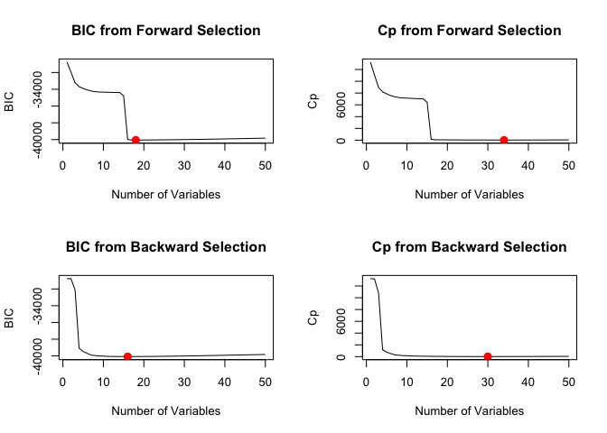

```r
# Subset model
fsub.fit = regsubsets(vannføring~ .-dato -vannstand -modellertvannføring, nvmax = 60, data = train, method="forward")

par(mfrow=c(2,2))

plot(summary(fsub.fit)$bic, xlab = "Number of Variables", ylab = "BIC", type = 'l', main = "BIC from Forward Selection")
l = which.min(summary(fsub.fit)$bic)
points(l, summary(fsub.fit)$bic[l], col="red", cex=2, pch=20)

plot(summary(fsub.fit)$cp, xlab = "Number of Variables", ylab = "Cp", type = 'l', main = "Cp from Forward Selection")
l = which.min(summary(fsub.fit)$cp)
points(l, summary(fsub.fit)$cp[l], col="red", cex=2, pch=20)

bsub.fit = regsubsets(vannføring~ .-dato -vannstand -modellertvannføring, nvmax = 60, data = train, method="backward")

plot(summary(bsub.fit)$bic, xlab = "Number of Variables", ylab = "BIC", type = 'l', main = "BIC from Backward Selection")
l = which.min(summary(bsub.fit)$bic)
points(l, summary(bsub.fit)$bic[l], col="red", cex=2, pch=20)

plot(summary(bsub.fit)$cp, xlab = "Number of Variables", ylab = "Cp", type = 'l', main = "Cp from Backward Selection")
l = which.min(summary(bsub.fit)$cp)
points(l, summary(bsub.fit)$cp[l], col="red", cex=2, pch=20)
```

We choose the covariates with the lowest BIC values from the backward selection.

```r
best = which.min(summary(bsub.fit)$bic)
coeffs = names(coef(bsub.fit, best))[2:length(coef(bsub.fit, best))]
train_subset = subset(train, select = c(coeffs))
train_subset["vannføring"] = train$vannføring

bestsub.fit = lm(vannføring~., data = train_subset)
summary(bestsub.fit)
```

```
##
## Call:
## lm(formula = vannføring ~ ., data = train_subset)
##
## Residuals:
##     Min      1Q  Median      3Q     Max
## -6.5348 -0.0508  0.0024  0.0466  9.6306
##
## Coefficients:
##                          Estimate Std. Error t value Pr(>|t|)
## (Intercept)              0.000887   0.002131   0.416 0.677202
## nedbør                   0.272651   0.002787  97.820  < 2e-16 ***
## snødekningsgrad          0.015829   0.004687   3.377 0.000734 ***
## snøvannekvivalent       -9.775936   0.116786 -83.708  < 2e-16 ***
## temperatur               0.031782   0.004274   7.437 1.09e-13 ***
## snøvannekvivalent1dager 11.405770   0.210328  54.229  < 2e-16 ***
## nedbør1dager            -0.068768   0.003463 -19.857  < 2e-16 ***
## vannføring1dager         0.751876   0.006344 118.524  < 2e-16 ***
## snøvannekvivalent2dager -1.362569   0.150341  -9.063  < 2e-16 ***
## nedbør2dager            -0.010323   0.002437  -4.236 2.29e-05 ***
## temperatur3dager        -0.025864   0.004237  -6.104 1.06e-09 ***
## vannføring3dager         0.022333   0.005079   4.397 1.10e-05 ***
## snøvannekvivalent7dager -0.266032   0.028684  -9.275  < 2e-16 ***
## month_5                  0.051322   0.002972  17.271  < 2e-16 ***
## month_6                  0.025547   0.002629   9.716  < 2e-16 ***
## month_9                  0.010742   0.002431   4.418 1.00e-05 ***
## month_10                 0.009962   0.002296   4.340 1.44e-05 ***
## ---
## Signif. codes:  0 '***' 0.001 '**' 0.01 '*' 0.05 '.' 0.1 ' ' 1
##
## Residual standard error: 0.2607 on 14951 degrees of freedom
## Multiple R-squared:  0.932,  Adjusted R-squared:  0.9319
## F-statistic: 1.281e+04 on 16 and 14951 DF,  p-value: < 2.2e-16
```

We see that by using backward selection, the optimal model has 16 variables, which are all significant in the model. We observe that the temperature, amount of snow and amount of precipitation on the day of measurement are important, as well as the response value, precipitation, snow amount and temperature from some of the past days. Interestingly, the model does not care about the snow amount at day 3, 4, 5, or 6, but the snow amount at day 7 becomes significant. The same can be seen for some of the other covariates. This could just be our model fitting noise in the data, but might also point to a delay in the covariates impact on the response, which the model manages to catch. Using the model on the test set yields the following MSE:

```r
bestsub.pred = predict(bestsub.fit, test)
mean((test$vannføring - bestsub.pred)^2)
```

```
## [1] 0.05414422
```

Notice that since all the traditional methods are ultimately linear regressions, it is straightforward to obtain inference about the coefficients in the models. As an example, one can easily find confidence intervals by using `confint()`.

The table below gives a summary of the three traditional methods. Notice that the intercept is not included when counting the variables in the last column of the table. Although the weighted linear regression outperforms the others in terms of predictive power, the subset selection is not far behind and have removed many non-significant variables.

| Algorithm | Test MSE | Adjusted R-squared | Variables |
| --- | --- | --- | --- |
| Linear Regression | 0.0548 | 0.9321 | 50 |
| Weighted Linear Regression | 0.0514 | 0.9384 | 50 |
| Subset Selection | 0.0541 | 0.9319 | 16 |

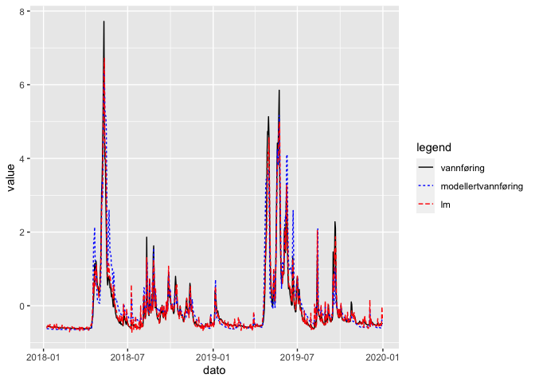

## Shrinkage models

In the data set we have a lot of covariates, many of which are not significant for our model. This motivates the use for shrinkage, or regularization, methods. These types of methods utilize the underlying assumption of simplicity in our data set, namely that only a few of the predictors actually play an important role in uncovering the signal in the data. We hope that by utilizing these types of methods we can remove/reduce the coefficients of the excessive covariates, to improve the prediction and interpretability of the model.

### Lasso model

The first model we will look at is the Lasso. The Lasso is a shrinkage method which utilizes a $L_1$ penalty to shrink and remove some of the covariates in the model. The lasso coefficients are given by

$$\hat{\beta}_{L} = \arg\min_{\beta} \left \{ \frac{1}{2}\sum_{i=1}^N (y_i - \beta_0 -\sum_{j=1}^p x_{ij}\beta_j)^2 + \lambda \sum_{j=1}^p |\beta_j| \right \},$$
where $N$ is the number of datapoints and $p$ is the number of covariates. To use this method we have to set the tuning parameter $\lambda$. One of the most common ways to do this is to do a cross validation. We will use the package glmnet’s own implementation of cross validaton for choosing the optimal $\lambda$, using 10 folds.

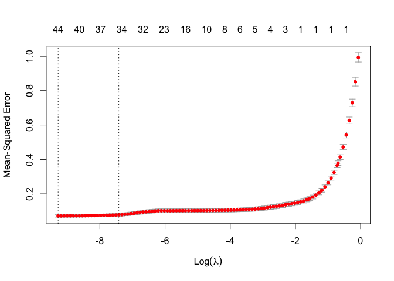

```r
start = glmnet(x = x_train, y = y_train, alpha = 1, standardize = FALSE)
autolambda = start$lambda
lambdagrid = c(autolambda, 0.5, 0.3, 0.2, 0.1)

lasso.fit = glmnet(x = x_train, y = y_train, alpha = 1, lambda = lambdagrid, nfolds = 10, standardize = FALSE)
cvlasso.fit = cv.glmnet(x_train, y_train, alpha = 1, lambda = lambdagrid, nfolds = 10, standardize = FALSE)

plot(cvlasso.fit)
```

Above we see a plot of the MSE from the cross validation for the different values of $\lambda$. The first vertical bar shows the optimal $\lambda$, while the second bar shows the $\lambda$ one standard error above the minimal value. By choosing the one standard error $\lambda$ we will choose a slightly simpler model, whose error is still within one standard error of the minimal one. From the plot it does not seem like a heavily regularized method will preform better than a full linear model. The optimal lambda value is very close to zero, meaning that there is almost no regularization of the coefficients happening. Since we have a lot of training data, the confidence intervals are tight. We calculate the test MSE for the different $\lambda$ values, as well as for $\lambda$ equal to 0 and 0.005.

[output not shown]

We see that as expected, $\lambda = 0$ yields the smallest test MSE. As $\lambda$ increases the test MSE increases. To gain the same number of non-zero coefficients as in the backward subset model, we have to use a $\lambda$ value of around 0.005. This yields a test MSE of 0.0960, which is an increase of the subset test MSE. We also meantion that the reason the $\lambda$ values are all very small, i.e. close to zero, is because we have standardized the data outside of the model. We take a look at the coefficients chosen by each model, for the minimum and 1se $\lambda$, as well as $\lambda = 0.005$:

```r
coefficients = cbind(coef(lasso.fit, s = cvlasso.fit$lambda.min), coef(lasso.fit, s = cvlasso.fit$lambda.1se), coef(lasso.fit, s = 0.005))
colnames(coefficients) = c("lambda min", "lambda 1se","lambda 0.005")
print(coefficients)
```

```
## 51 x 3 sparse Matrix of class "dgCMatrix"
##                            lambda min    lambda 1se  lambda 0.005
## (Intercept)              8.904526e-04  0.0009513065  6.509114e-04
## nedbør                   2.471239e-01  0.2016318850  1.261992e-01
## snødekningsgrad          .             .             .
## snøvannekvivalent       -7.852124e+00 -4.6533200686  .
## temperatur               5.085999e-02  0.0643686664  7.135122e-02
## snøvannekvivalent1dager  7.769472e+00  3.4750139079  .
## snødekningsgrad1dager    3.733157e-02  0.0374518762  3.021299e-02
## nedbør1dager            -4.823796e-02 -0.0424656032 -7.704156e-02
## temperatur1dager        -1.090590e-02  .             .
## vannføring1dager         7.539291e-01  0.7844206302  8.714814e-01
## snøvannekvivalent2dager  4.110786e-01  1.1962266770  .
## snødekningsgrad2dager    .             .             .
## nedbør2dager            -5.103293e-03  .            -1.322134e-02
## temperatur2dager        -1.269575e-02 -0.0248824352  .
## vannføring2dager        -2.731415e-02 -0.0408767939 -4.717691e-04
## snøvannekvivalent3dager  1.073330e-02  .             .
## snødekningsgrad3dager    3.276168e-05  .             .
## nedbør3dager            -4.867624e-03  0.0026619946  .
## temperatur3dager        -1.162007e-02 -0.0090396999 -9.990584e-03
## vannføring3dager         3.452410e-02  0.0163678015  .
## snøvannekvivalent4dager  .             .             .
## snødekningsgrad4dager   -3.475447e-02 -0.0113082642  .
## nedbør4dager            -2.716012e-03  0.0030452279  .
## temperatur4dager        -5.784276e-03 -0.0049332465  .
## vannføring4dager         7.097348e-03  0.0081437383  .
## snøvannekvivalent5dager  .             .             .
## snødekningsgrad5dager    1.323920e-02  .             .
## nedbør5dager            -4.386619e-03  0.0012140094  .
## temperatur5dager        -1.015725e-03 -0.0029049669  .
## vannføring5dager         9.299837e-03  0.0021384966  .
## snøvannekvivalent6dager  .             .             4.116020e-04
## snødekningsgrad6dager    .             .             .
## nedbør6dager            -5.730996e-03  0.0017277408  .
## temperatur6dager        -1.819927e-03  .             .
## vannføring6dager         1.968955e-02  0.0052229922  .
## snøvannekvivalent7dager -3.233107e-01  .             1.138600e-02
## snødekningsgrad7dager   -1.123374e-03 -0.0041863014  .
## nedbør7dager             1.816387e-04 -0.0002230310  .
## temperatur7dager         8.520239e-04  .             .
## vannføring7dager        -1.741014e-02 -0.0002349958  .
## month_2                 -4.613250e-03 -0.0058235352 -9.283877e-05
## month_3                 -8.782665e-03 -0.0111088151 -5.310503e-03
## month_4                 -6.750932e-03 -0.0072778024  .
## month_5                  5.148598e-02  0.0563492954  6.792133e-02
## month_6                  2.729155e-02  0.0263720372  2.016499e-02
## month_7                  4.404945e-03  0.0014202807  .
## month_8                  2.339934e-03  .             .
## month_9                  1.354929e-02  0.0124016000  4.869285e-03
## month_10                 1.213453e-02  0.0111196040  4.256393e-03
## month_11                 3.445714e-03  0.0012079778  .
## month_12                 1.338398e-03  .             .
```

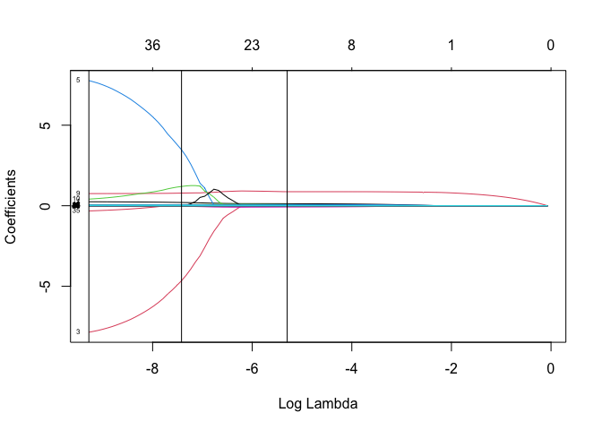

```r
plot(lasso.fit, xvar = "lambda", label = TRUE)
abline(v=log(cvlasso.fit$lambda.min))
abline(v=log(cvlasso.fit$lambda.1se))
abline(v=log(0.005))
```

We see that some of the coefficients decrease and then increase again. This might indicate that Lasso is not suitable for our problem.

From a pure prediction point of view, the best model would be the one yielding the smallest test MSE, which is the one with the smallest $\lambda$ value.

```r
cvlasso.pred = predict(lasso.fit, s = cvlasso.fit$lambda.min, newx = x_test)
mean((y_test - cvlasso.pred)^2)
```

```
## [1] 0.05798316
```

In the traditional linear models studied above it is easy to determine the significance of the included variables. Doing this for the Lasso proves more of a challenge. One way to do this is to use the Bayesian lasso, which will give us the posterior distributions for the $\beta_j$ in the model. Another is to use bootstrapping. Since we have enough data to have a separate test set, we will use a slightely simpler method where we use the selected covariates from lasso in a linear model, fitted on the test data. From this we can get an estimate of the p-value and confidence interval of the coefficients $\beta_j$. In this way lasso is only used for model selection, while a linear regression model is used for the model assessment. We will use the 16 variables chosen by the lasso model with $\lambda = 0.005$.

```r
#coef(lasso.fit, s = 0.005)
coeffs = c("nedbør", "temperatur", "snødekningsgrad1dager", "nedbør1dager",
           "vannføring1dager", "nedbør2dager", "vannføring2dager", "temperatur3dager",
           "snøvannekvivalent6dager", "snøvannekvivalent7dager",
           "month_2", "month_3", "month_5", "month_6", "month_9", "month_10")

lasso_subset = subset(test, select = c(coeffs))
lasso_subset["vannføring"] = test$vannføring

inference.fit = lm(vannføring~., data = lasso_subset)
summary(inference.fit)
```

```
##
## Call:
## lm(formula = vannføring ~ ., data = lasso_subset)
##
## Residuals:
##      Min       1Q   Median       3Q      Max
## -2.68932 -0.10267 -0.02640  0.06956  1.45235
##
## Coefficients:
##                          Estimate Std. Error t value Pr(>|t|)
## (Intercept)             -0.017396   0.010900  -1.596 0.110949
## nedbør                   0.088884   0.011556   7.692 4.89e-14 ***
## temperatur               0.127032   0.021486   5.912 5.25e-09 ***
## snødekningsgrad1dager    0.091980   0.026119   3.522 0.000457 ***
## nedbør1dager            -0.096331   0.012444  -7.741 3.41e-14 ***
## vannføring1dager         1.179376   0.035394  33.321  < 2e-16 ***
## nedbør2dager             0.007626   0.012185   0.626 0.531614
## vannføring2dager        -0.282241   0.036871  -7.655 6.38e-14 ***
## temperatur3dager        -0.005448   0.022319  -0.244 0.807238
## snøvannekvivalent6dager  1.121245   0.420889   2.664 0.007898 **
## snøvannekvivalent7dager -1.075270   0.418884  -2.567 0.010463 *
## month_2                 -0.014505   0.012184  -1.190 0.234252
## month_3                 -0.018182   0.013138  -1.384 0.166819
## month_5                  0.029661   0.014570   2.036 0.042151 *
## month_6                  0.023002   0.011890   1.935 0.053442 .
## month_9                  0.031067   0.012358   2.514 0.012162 *
## month_10                 0.016338   0.011692   1.397 0.162757
## ---
## Signif. codes:  0 '***' 0.001 '**' 0.01 '*' 0.05 '.' 0.1 ' ' 1
##
## Residual standard error: 0.2848 on 706 degrees of freedom
## Multiple R-squared:  0.9234, Adjusted R-squared:  0.9217
## F-statistic:   532 on 16 and 706 DF,  p-value: < 2.2e-16
```

We see that only about half of the 16 covariates have a p-value which would be considered significant. We can also look at the 95% confidence intervals below.

```r
confint(inference.fit, level = 0.95)
```

```
##                                 2.5 %       97.5 %
## (Intercept)             -0.0387965744  0.004004574
## nedbør                   0.0661960720  0.111571354
## temperatur               0.0848480462  0.169216445
## snødekningsgrad1dager    0.0406993275  0.143260408
## nedbør1dager            -0.1207618995 -0.071899976
## vannføring1dager         1.1098864678  1.248866137
## nedbør2dager            -0.0162976356  0.031550080
## vannføring2dager        -0.3546317345 -0.209851034
## temperatur3dager        -0.0492664828  0.038371279
## snøvannekvivalent6dager  0.2949003980  1.947589857
## snøvannekvivalent7dager -1.8976767094 -0.252863320
## month_2                 -0.0384259963  0.009416173
## month_3                 -0.0439754599  0.007612117
## month_5                  0.0010547237  0.058266860
## month_6                 -0.0003419265  0.046345682
## month_9                  0.0068040246  0.055330846
## month_10                -0.0066178281  0.039292862
```

For the significant variables, the 95% confidence intervals seem good as they tightly fit the data. For all the non-significant variables, the confidence intervals all include 0, which implies that these are perhaps not the best subset of predictors. All of this indicates that lasso might not be the best method for our type of temporal data.

We also plot the prediction of `vannføring` from the lasso model with $\lambda_{min}$ from the cv for the year 2018 and 2019. We see that the prediction is very similar to the one from the linear model, which is not surprising given that the models are very similar. The regularized method did not manage to decrease the variability in the predition at the lower water levels.

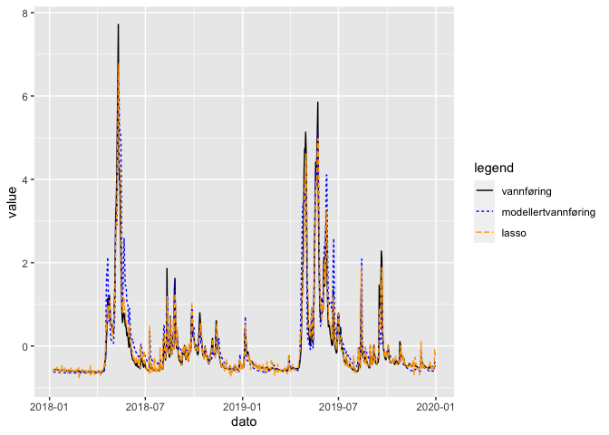

### Elastic net model

We have seen that the normal lasso with the $L_1$ penalty was not well suited for our data in terms of prediction power. We therefore consider some generalizations of the lasso, obtained by varying the loss function. By comparing the $L_1$ and $L_2$ penalty we obtain the elastic net method. This method might deal better with the correlated groups in our data. The elastic net coefficients are given by

$$\hat{\beta}^{elastic \ net} = \arg\min_{\beta} \left \{ \frac{1}{2}\sum_{i=1}^N (y_i - \beta_0 -\sum_{j=1}^p x_{ij}\beta_j)^2 + \lambda \sum_{j=1}^p ((1-\alpha)\beta_j^2 + \alpha|\beta_j|) \right \},$$

```r
control <- trainControl(method = "repeatedcv",
                              number = 5,
                              repeats = 5,
                              search = "random")

elastic_model <- train(vannføring~.-dato -vannstand -modellertvannføring,
                       data = train,
                       method = "glmnet",
                       tuneLength = 25,
                       trControl = control)
elastic_model
```

```
## glmnet
##
## 14968 samples
##    53 predictor
##
## No pre-processing
## Resampling: Cross-Validated (5 fold, repeated 5 times)
## Summary of sample sizes: 11975, 11975, 11973, 11974, 11975, 11976, ...
## Resampling results across tuning parameters:
##
##   alpha        lambda       RMSE       Rsquared   MAE
##   0.003306765  0.015914906  0.3202514  0.8974594  0.1682039
##   0.071704568  0.004710259  0.3110949  0.9029987  0.1604997
##   0.097933619  0.001144268  0.3008520  0.9092585  0.1529689
##   0.126741726  0.025783429  0.3214217  0.8967786  0.1657580
##   0.251710097  0.052583971  0.3301259  0.8922712  0.1643898
##   0.253030392  0.013269534  0.3184228  0.8984863  0.1635639
##   0.256572446  0.001595511  0.3043190  0.9071571  0.1550217
##   0.271335769  0.011111386  0.3182596  0.8985539  0.1635988
##   0.311409417  0.115645004  0.3538716  0.8804229  0.1703987
##   0.348821849  0.001617303  0.3048918  0.9068067  0.1552262
##   0.352680931  0.005178467  0.3166231  0.8995315  0.1628590
##   0.455995593  0.082787681  0.3441616  0.8859056  0.1632606
##   0.468982243  0.161295314  0.3735361  0.8748072  0.1896641
##   0.510668324  0.670046066  0.5756456  0.8523560  0.3472806
##   0.641323441  3.297415450  0.9986000        NaN  0.6415347
##   0.669586562  3.004821501  0.9986000        NaN  0.6415347
##   0.694333869  0.001741399  0.3089148  0.9043316  0.1574505
##   0.734343350  0.098081757  0.3572622  0.8808735  0.1761556
##   0.817178369  2.763702005  0.9986000        NaN  0.6415347
##   0.825062730  0.536665892  0.6010242  0.8718849  0.3699938
##   0.847326750  0.269635158  0.4391135  0.8716845  0.2502419
##   0.886467427  2.408379468  0.9986000        NaN  0.6415347
##   0.941385330  0.001189341  0.3022550  0.9083916  0.1525475
##   0.963907664  0.490311361  0.5984194  0.8728812  0.3684169
##   0.982043213  0.196748238  0.4066522  0.8728812  0.2236092
##
## RMSE was used to select the optimal model using the smallest value.
## The final values used for the model were alpha = 0.09793362 and lambda
##  = 0.001144268.
```

From the cross validation results $\alpha =$ 0.0979336 and $\lambda =$ 0.0011443 are chosen as the optimal values yielding the lowest RMSE. Normally, we should be careful simply choosing the parameters yielding the smallest error, as there could still be some overfitting happening even though the risk of this is mitigated some when using cross validation. In this case we have a lot of training data from many years, and we don’t expect the variance in the data between the training years is any smaller than for normal years. We would therefore not expect much overfitting during our fitting, especially not for non-flexible models like elastic net.

```r
elastic.fit = glmnet(x = x_train, y = y_train, alpha = elastic_model$bestTune$alpha, lambda = elastic_model$bestTune$lambda, standardize = FALSE)

elastic.pred = predict(elastic.fit, s = elastic_model$bestTune$lambda, newx = x_test)
mean((y_test - elastic.pred)^2)
```

```
## [1] 0.08052763
```

The value is higher than the error from the lasso with the smallest optimal $\lambda$ value. It also includes more variables, which we see as a setback in this problem, as we do not think all 46 variables are needed to explain most of the variability in the response. We conclude that an elastic net model does not perform better than lasso for our observations, and that both have proven not suitable for our temporal problem.

Since we have a temporal aspect to our data, we might wish for continuity in time-neighboring coefficients. The fused lasso is a method naturally tailored to such situations.

### Generalized lasso variants - Fused lasso

We can generalize the lasso to imbue our model with more specific properties. The generalized lasso is defined by HTW (https://web.stanford.edu/~hastie/StatLearnSparsity/) as

$$\hat{\beta}_{GL} = \arg\min_{\beta} \frac{1}{2} \|Y - X\beta\|_2^2 + \lambda \|D\beta\|_1,$$
for some linear operator $D$ and regularization parameter $\lambda$. Here we also use a slightly more compact notation than earlier. The range of $D$ should be some space where we wish to look for a sparse solution. If we chose $D = I$, we arrive at the normal lasso. If we select $D$ as a difference matrix, i.e a matrix with $1$ on the diagonal, $-1$ on upper diagonal and $0$ elsewhere, we arrive at the so-called fused lasso. The fused lasso can be suited for problems with some notion of time or space relationship. In this case it can select $\beta$ that are more piece-wise constant with respect to time or space, which means the resulting linear model will be piece-wise smoother in time or space. As the regularization parameter $\lambda$ increases, the resulting linear model a model where all components of $\beta$ have the same values.

In our previous models we have seen that linear models will produce “noisy”, non-smooth predictions, especially for low prediction values. It is therefore worth investigating a fused lasso model to see if we can achieve a smoother model, hopefully without losing prediction power. Unlike the fused lasso described above, each of our covariates $\text{covariates} = [\texttt{vannføring}, \texttt{nedbør}, \texttt{temperatur}, \texttt{snøvannekvivalent}, \texttt{snødekningsgrad}]$ with their corresponding covariates backwards in time have a relationship in time, but not a relationship we want to shrink between themselves. We therefore select the matrix $D$ so that the resulting fused lasso model, written in a slightly more compact way than before, becomes
$$\hat{\beta}_{FL} = \arg\min_{\beta} \frac{1}{2} \|Y - X\beta\|_2^2 + \lambda \sum_{i \in \text{covariates}} \sum_{j=0}^\text{days-1} | \beta_{i,j} - \beta_{i,j+1}|.$$
We use the R package `genlasso` to fit our fused lasso model. This package does not have a built in parameter selection method, but rather returns different fits for a range of parameters $\lambda$. This parameter could be chosen by the methods discussed earlier in this text, but for now we are more interested in what type of fits we obtain for different parameters $\lambda$. We can also extend the fused lasso model by adding an additional penalty term $\gamma \|\beta\|_1$ for some $> 0 $ to also shrink the parameters similarly to normal lasso. However, we have seen so far that full linear models perform well on this problem, and we do not apply this additional penalty term. We fit the described fused lasso model to the training set similarly as earlier methods and test the method for different parameters $\lambda$ on a test set.

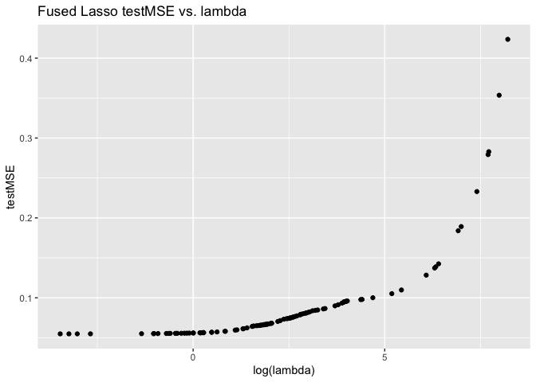

```r
# D matrix as described earlier
fusedLasso = fusedlasso(y_train,x_train,D, gamma = 0.0,maxsteps=10000)
nlam = length(fusedLasso$lambda)

newy = predict.genlasso(fusedLasso,Xnew=x_test)
testMSE = rep(0,nlam)
for (i in 1:nlam){
  newyfit = newy$fit[,i]
  testMSE[i] = mean((test$vannføring - newyfit)^2)
}

qplot(x = log(fusedLasso$lambda), y = testMSE) + ggtitle("Fused Lasso testMSE vs. lambda") + xlab("log(lambda)") + ylab("testMSE")
```

The resulting plot of test MSE versus regularization parameter is very similar to the similar plot for normal lasso, except this time we use an actual test MSE instead of a cross-validation statistic. We see that in order to obtain a model with good prediction properties, we want almost no regularization. This is not particularly interesting to us, as this model is nearly indistinguishable from a linear model. Instead, in order to investigate some of the properties of a fused lasso model, we choose a model with high $\lambda$, which has over double the test MSE of the standard linear model.

```r
newyfit = newy$fit[,6]
FLbeta = fusedLasso$beta[,6]
testMSE[6]
```

```
## [1] 0.1891391
```

```r
names = names(train)
names = names[! names %in% c("vannføring","vannstand","modellertvannføring","dato")]
names(FLbeta) = names
FLbeta
```

```
##                  nedbør         snødekningsgrad       snøvannekvivalent
##             0.060346114             0.014753182             0.005769083
##              temperatur snøvannekvivalent1dager   snødekningsgrad1dager
##             0.007986268             0.005769083             0.014753182
##            nedbør1dager        temperatur1dager        vannføring1dager
##            -0.002543363             0.007986268             0.338883501
## snøvannekvivalent2dager   snødekningsgrad2dager            nedbør2dager
##             0.005769083             0.014753182            -0.002543363
##        temperatur2dager        vannføring2dager snøvannekvivalent3dager
##             0.007986268             0.338883501             0.005769083
##   snødekningsgrad3dager            nedbør3dager        temperatur3dager
##             0.014753182            -0.002543363             0.007986268
##        vannføring3dager snøvannekvivalent4dager   snødekningsgrad4dager
##             0.023294664             0.005769083             0.014753182
##            nedbør4dager        temperatur4dager        vannføring4dager
##            -0.002543363             0.007986268             0.023294664
## snøvannekvivalent5dager   snødekningsgrad5dager            nedbør5dager
##             0.005769083             0.014753182            -0.002543363
##        temperatur5dager        vannføring5dager snøvannekvivalent6dager
##             0.007986268             0.023294664             0.005769083
##   snødekningsgrad6dager            nedbør6dager        temperatur6dager
##             0.014753182            -0.002543363             0.007986268
##        vannføring6dager snøvannekvivalent7dager   snødekningsgrad7dager
##             0.023294664             0.005769083             0.014753182
##            nedbør7dager        temperatur7dager        vannføring7dager
##            -0.002543363             0.007986268             0.023294664
##                 month_2                 month_3                 month_4
##            -0.006217642            -0.014512220             0.007992256
##                 month_5                 month_6                 month_7
##             0.141932005             0.094605403             0.071032180
##                 month_8                 month_9                month_10
##             0.072147260             0.084563424             0.065834767
##                month_11                month_12
##             0.019735822             0.008007519
```

Inspecting the chosen coefficients we see that none of them are $0$ as expected. To keep things readable we print only the variables:

```r
FLbeta[c("nedbør", "nedbør1dager", "nedbør2dager", "nedbør3dager", "nedbør4dager", "nedbør5dager", "nedbør6dager", "nedbør7dager")]
```

```
##       nedbør nedbør1dager nedbør2dager nedbør3dager nedbør4dager nedbør5dager
##  0.060346114 -0.002543363 -0.002543363 -0.002543363 -0.002543363 -0.002543363
## nedbør6dager nedbør7dager
## -0.002543363 -0.002543363
```

We plot the prediction on part of the test set.

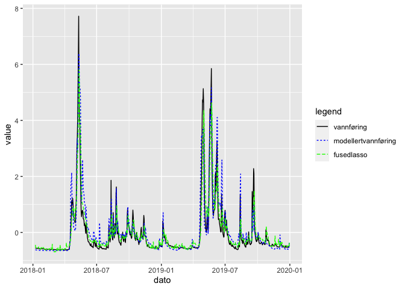

```r
# Rekkefølge på ting som skal plottes
variable_vec = c("vannføring", "modellertvannføring", "fusedlasso")

test %>%
  dplyr::mutate(fusedlasso = newyfit) %>%
  tidyr::pivot_longer(tidyselect::all_of(variable_vec)) %>%
  dplyr::mutate(name = factor(name, levels = variable_vec)) %>%
  ggplot(aes(x = dato, y = value, group = name, col = name, linetype = name)) +
  geom_line() +
  scale_color_manual(values = c("black", "blue", "green")) +
  labs(col = "legend", linetype = "legend")
```

# Comparison and conclusion

We will now attempt to summarize and discuss some of our results. It is quite remarkable that linear models work so efficiently on this problem. One would think that a standard linear model would have too high variance to be of any use. Furthermore, one would expect that a simple linear model would be unable to capture the non-linearities and dependence in the data. However, for this specific data set, linear models seem to outperform the existing HBV model when measuring MSE. Furthermore, linear models allow for inference and calculation of confidence intervals to a greater degree than a purely physical model. It is somewhat disappointing that more sophisticated models like the lasso and the fused lasso do not outperform standard linear regression, but we have seen that they can have some useful properties.

When that is said, there are some parts of our modeling and application of linear models that should be more looked into:

- It is clear from our results with shrinkage models that the linear models can be shrunk significantly and produce similar results as full models. This motivates the use of shrinkage models as a tool to increase model interpretability. There also exists techniques for inference on shrinkage models, some of which we have applied in this report. It is still unclear what type of shrinkage model is best for this problem.
- The assumption that we have information about `temperatur`, `nedbør`, `snødekningsgrad` and `snøvanninnhold` from the same day, or even the previous days, when we are predicting `vannføring` is unlikely. We have imagined that this data is obtained from separate models. However, the linear models we have applied do not necessarily capture the extra uncertainty introduced by additional models. This is a big hurdle to overcome if such models are to be used in practice.
- How many days backwards in time should be included in a linear model? Using more data leads to larger, possibly overfitted and “bloated” models. This also introduces some data leakage in models where methods similar to cross validation is used for parameter selection. Linear models are relatively cheap to compute, but computation time should also be taken into account as the size of the linear models increase.
- How much data should be trained and tested on? This is a problem for all data-driven models, which also includes the HBV model. In general, useful available data should improve a learned model. However, the data in this case goes far back in time, and it is possible that not all data is reliable and that the river we are trying to model changes over time.
- Can similar models be applied to other locations, or is Eggafoss a special case? It is not clear if a similar approach will give similar results for other locations. It is possible that linear models are ineffective at other locations, and that some locations require shrinked models in order to be effective. When considering more than one location, it could also be interesting to see if there is some statistical relationship between several locations.
- We have seen that purely data-driven models has potential for predicting water flow. It is worth investigating more advanced models? Also, how should the effectiveness of such models be measured? In this report we have used MSE to measure accuracy, but is this the best measure for water flow prediction?

We summarize our results in the following table.

[output not shown]